Enhanced analgesic activity by cyclodextrins - A systematic review and meta-

analysis

**Article** *in* Expert Opinion on Drug Delivery · July 2015

DOI: 10.1517/17425247.2015.1046835 · Source: PubMed

CITATIONS

56

READS

425

**5 authors**, including:

[figure not shown]

Vitiligo View project

[figure not shown]

Phytol, a alcohol diterpene derived from chlorophyll A, attenuates adjuvant-induced arthritis in mice View project

Renan Brito

Universidade Tiradentes

**44** PUBLICATIONS **815** CITATIONS

SEE PROFILE

Adriano A S Araújo

Universidade Federal de Sergipe

**233** PUBLICATIONS **5,835** CITATIONS

SEE PROFILE

Jullyana Quintans

Universidade Federal de Sergipe

**202** PUBLICATIONS **4,592** CITATIONS

SEE PROFILE

Kathleen Sluka

University of Iowa

**349** PUBLICATIONS **22,567** CITATIONS

SEE PROFILE

1.

Introduction

2.

Methods

3.

Results

4.

Discussion

5.

Conclusion

6.

Expert opinion

Review

Enhanced analgesic activity by

cyclodextrins -- a systematic

review and meta-analysis

Renan G Brito, Adriano AS Ara�ujo, Jullyana SS Quintans,

Kathleen A Sluka & Lucindo J Quintans-J�unior†

†Federal University of Sergipe, Department of Physiology, Sergipe, Brazil

Introduction: Analgesics can be ineffective in treating some types of pain,

hence, improved drug delivery systems could optimize their efficacy.

Area covered: The authors conducted a systematic review to evaluate the

analgesic activity of compounds complexed in cyclodextrins, analyzing

whether these complexes improved analgesic efficacy. The search terms

‘analgesics’, ‘cyclodextrins’ and ‘drug effects’ were used to retrieve articles

in SCOPUS, PUBMED and EMBASE. A total of 22 papers were identified. In

the clinical studies, there was greater efficacy in the complexed drug when

compared with control groups, with differences ranging from 25 to 83%.

Through a meta-analysis, the preclinical studies showed that the complexed

drug had a significantly (p < 0.01) greater effect than the non-complexed

drug.

Expert opinion: The use of cyclodextrins can improve the efficacy of analgesic

compounds, and they are an important tool in the search for greater analge-

sic effect. They may also be a way to reduce the therapeutic doses, and hence

increasing the potential of the drug.

Keywords: analgesics, cyclodextrins, drug effects, meta-analysis, pain, systematic review

Expert Opin. Drug Deliv. [Early Online]

1. Introduction

Pain is defined as an unpleasant sensory and emotional experience associated with

actual or potential tissue damage, or described in terms as such damage. Pain is

recognized as a public health problem with significant physical and psychological

consequences [1]. The average prevalence of acute and chronic pain in the adult pop-

ulation ranges around 15% [2,3], resulting in an annual spending, in the US alone, in

the order of US $ 635 billion [4].

Pharmacotherapy is widely used in the treatment of pain. Several classes of drugs

are common, including opioids, non-steroidal anti-inflammatories (NSAIDs), mus-

cle relaxants, anticonvulsants and antidepressants are the most widely used

drugs [5,6]. However, 40 -- 60% of patients do not respond appositely to the therapy,

and may have partial reductions in pain or significant side effects [7,8]. Thus, various

types of drugs with an analgesic profile, such as NSAIDs, have been incorporated

into drug delivery systems, such as cyclodextrins (CDs), to improve pharmacologi-

cal properties [9].

CDs have been known for over 100 years. They were first discovered in 1891 by

Villiers, a French scientist. He isolated about 3 g of a crystalline substance from

1000 g of starch and determined its composition as (C6H10O5)2·3H2O [10]. The

first patent on CDs and their complexes was registered in 1953 in the US. However,

until 1970 only small amounts of CDs were produced and high production costs

prevented their widespread usage in pharmaceutical formulations. With recent

10.1517/17425247.2015.1046835 © 2015 Informa UK, Ltd. ISSN 1742-5247, e-ISSN 1744-7593

1

All rights reserved: reproduction in whole or in part not permitted

For personal use only.

biotechnological advancements, the production of CDs has

improved and production costs have been lowered [11].

CDs are cyclic oligosaccharides consisting of six (aCD),

seven (bCD), eight (gCD) or more glucopyranose units

linked by a-(1,4) bonds. The sugar units adapt to a <sup>4</sup>C1 chain

conformation and are orientated in such a way that the mole-

cule forms a toroidal truncated cone structure [12,13]. CDs are

pharmaceutically useful due to the fact that they can interact

with drug molecules to form inclusion complexes. In forming

inclusion complexes, major changes in candidate drug proper-

ties, including enhanced solubility, pharmacological bioavail-

ability, chemical stability and physical profile, have been

reported [14-16]. Such changes have then resulted in a better

biological performance, and thus in the use of CDs in various

commercially successful pharmaceutical products [17,18].

In this context, the present study aimed to assess, through a

systematic review and meta-analysis, the studies that evaluated

the analgesic activity of analgesic compounds complexed in

CDs, analyzing whether the drug encapsulation improves

the analgesic profile.

2. Methods

2.1 Systematic review

This systematic review was conducted in accordance with the

guidelines of Transparent Reporting of Systematic Reviews

and Meta-Analyses (PRISMA statement) [19]. A literature

search was performed in January 2014 and included articles

published over a period of 14 years (January 2000 to January

2014). This literature search was performed through special-

ized databases (PUBMED, SCOPUS and EMBASE) using

different

combinations

of

the

following

keywords:

‘Analgesics’, ‘Cyclodextrins’ and ‘Drug effects’ either as

MeSH terms or as free-text words. The inclusion criteria

used were: both preclinical and clinical studies that investi-

gated analgesic action and the use of CDs to improve analge-

sia, published between January 2000 and January 2014 and

written in English.

For the selection of the manuscripts, two independent

investigators (R.G.B. and J.S.S.Q.) first selected the articles

according to the title. The abstract was used to consider inclu-

sion criteria, and then assessment of the full-text publication

confirmed the inclusion criteria and extracted data. The

disagreements, which happened two times, were resolved

through consensus. The resulting articles were manually

reviewed with the goal of identifying studies that met the

inclusion criteria described above.

2.2 Risk of bias in clinical studies included

In order to assess the ‘risk of bias’, clinical studies were judged

on

the

following

items:

random

sequence

generation,

allocation, blinding, incomplete outcome data and sources

of funding bias using criteria outlined by the Cochrane Col-

laboration [20]. The overall risk of bias in the seven clinical

studies was classified as high, low or unclear.

2.3 Data analyses

Clinical Studies: The clinical studies did not have enough

similar data to perform a meta-analysis as comparison groups

were mixed. We determined the extent to which the CD-

complexed drug improved the analgesia when compared

with placebo, standard drug, vehicle, baseline or the drug

alone by calculating the percentage of the analgesic improve-

ment (AI). For those clinical studies with Visual Analog Scale

(VAS) scores provided, the following formula was used to cal-

culate the percentage improvement in pain: AI = ((Mean

VASExperimental - Mean VASControl)/Mean VASControl)) � 100.

Preclinical studies: we performed a meta-analysis using the

software Open Meta.[Analyst] 2013. The data from the pub-

lished trials were divided into three groups and a separate

analysis was performed for each one: thermal, chemical and

nociceptive score. We extracted the sample size, means and

standard deviations for each measure for the individual

papers. When the same study had two or more assessments

in the same group of animals, we used the assessment with

the greatest effect. For the meta-analyses, we only included

studies that compared the drug complexed with CD to the

drug alone. Three studies were, therefore, not included in

the meta-analysis as they compared the complexed drug to

the vehicle. Two additional studies were also excluded because

we could not extract all data required for the meta-analysis.

For all studies when multiple doses were tested, we extracted

data from the dose with the greatest analgesic effect.

3. Results

This review searched studies that evaluated the effectiveness of

substances complexed in CDs in the analgesic activity. The

primary search identified 329 articles: 190 from PUBMED,

81 from SCOPUS and 58 from EMBASE. After screening,

47 articles met the inclusion criteria: 14 from PUBMED,

14 from SCOPUS and 19 from EMBASE. Out of this total,

25 were indexed in two or more databases and were consid-

ered only once, resulting in 22 articles selected for final anal-

ysis. Seven publications were clinical and 15 were preclinical.

Article highlights.

. Cyclodextrins (CDs) are one of the most interesting drug

encapsulation systems for analgesic and

anti-inflammatory drugs already used in medicine.

. CDs can easily form complexes with analgesic drugs and

they can improve the pharmacological efficacy.

. CDs can act using decreasing doses of analgesic drugs,

which may reduce any side effects.

. There are few studies sufficiently providing evidence of

why this improvement occurs.

. Preclinical studies have a key role to understand how

the CDs can advance analgesic profiles.

This box summarizes key points contained in the article.

R. G. Brito et al.

2

Expert Opin. Drug Deliv. (2015) 12(10)

For personal use only.

A flowchart illustrating the progressive study selection and

numbers at each stage is shown in Figure 1. The general char-

acteristics of the clinical and preclinical studies identified by

this systematic review are described in Tables 1 and 2.

Using the assessment for risk of bias, sequence generation

was judged to be adequate in six studies, incomplete outcome

data were adequate in six studies, four had adequate assessor

and participant blinding and the source of funding bias was

clear in six. The allocation concealment was unclear in six

studies and with high risk of bias in one. Figure 2 provides

details of the judgments about each methodological quality

item for each study and Figure 3 provides a summary of overall

risk of bias in the seven studies as high, low or unclear.

The seven clinical studies selected by this systematic review

compared the use of NSAIDs complexed with CDs (Table 3).

Among those, three were compared with placebo, two were

compared with the CD-free drug, one was compared with

the baseline and one was compared with another NSAID,

naproxen. Five of the seven studies provided VAS pain scores,

for which we calculated percent reduction in pain. Of those

that were compared with placebo, the CD-free drug, baseline

or standard drug, there was (n = 5) a reduction in pain inten-

sity between 25 and 83%. Two studies normalized VAS scores

and provided total pain relief or pain intensity differences for

each group, demonstrating an improvement in the analgesic

effect by the complexed drug. One study did not find any dif-

ference in the analgesic profile when compared with another

NSAID. However, there were fewer side effects related to

gastrointestinal tract, suggesting an improvement in the

gastrointestinal tolerability to the complexed drug.

The preclinical studies evaluated the analgesic effect of dif-

ferent complexed drugs including NSAIDs, natural products,

opioids, local anesthetic and antidepressants. The preclinical

studies compared complexed drugs in CDs with the vehicle

or the drug alone. Several analgesic protocols were used and

classified into three broad categories: thermal, chemical and

nociceptive score. Thermal tests included the tail-flick and

hot-plate tests in uninjured animals. Chemical tests included

the acetic acid-induced abdominal constrictions and the for-

malin. In the nociceptive score group, a subjective nociceptive

assessment of animal response to injury was used (neuropathic

pain). The meta-analysis from the chemical group demon-

when compared with the drug alone (Figure 4A). In the

thermal group, the complexed drug increased significantly

plate or tail-flick tests when compared with the drug alone

score with the complexed drug compared to the drug alone

(Figure 4C). Thus, all conditions clearly show an enhanced

relief of pain behaviors for the complexed drug when

compared to the drug alone.

Some clinical and preclinical studies also reported an

improvement in other aspects. Among the clinical studies,

one study showed an increase in the time of action when the

complexed

and

non-complexed

drugs

were

compared;

another one demonstrated an increase in the gastrointestinal

tolerability when the complexed drug was compared with

two in absorption, one in oral delivery, one in permeability,

one in bioavailability and one in the drug release when com-

pared with the drug alone. In addition, two preclinical studies

showed a decrease in the cytotoxicity when the complexed

drug was compared with the drug alone. The other improve-

ment aspects are summarized in Table 4.

4. Discussion

The current systematic review showed that analgesics com-

plexed with CDs were effective when compared with the

drug alone, placebo or vehicle. Clinical studies have already

tested the complexed-NSAIDs diclofenac (DF) [21,22], piroxi-

cam (PX) [23-26] and nimesulide (NM) [27]. The clinical studies

generally show good methodological quality and demonstrate

the effectiveness of CDs in a variety of pain conditions. The

preclinical studies used complexes with natural products

(Lippia grata essential oil [EO] [28], (-)-linalool [LIN] [29],

p-cymene [pCM] [14]), NSAIDs (indomethacin [30], acetyl

salicylic acid [31], etoricoxib [32], meloxicam [33], etodolac [34,35]

and ketoprofen [36]), cannabinoids (MDA7 [37]), steroids (allo-

pregnanolone and alphaxalone [38]), local anesthetic (tetracaine

(TTC) [39]), opioid (sufentanil (SUF) [40]) and antidepressant

[figure not shown]

[figure not shown]

Identified studies: 329

Selected studies: 47

Duplicated: 25

Clinical: 7

Pre-Clinical: 15

Studies used: 22

Pubmed: 190

Scopus: 81

Embase: 58

Pubmed: 14

Scopus: 14

Embase: 19

Figure 1. Flow chart of the search and selection results.

CDs improving analgesic drugs

Expert Opin. Drug Deliv. (2015) 12(10)

3

For personal use only.

(doxepin (DOX) [41]). A variety of pain measures were used

including chemical, thermal and nociceptive score tests. In all

cases, there was a significantly better analgesic effect of

CD-complexed drugs when compared with the drug alone.

4.1 Clinical studies

Several NSAIDs, including DF, PX and NM, have been

complexed with CDs to improve analgesic efficacy in clinical

populations.

This

class

of

drugs

has

analgesic,

anti-

inflammatory and anti-pyretic profiles. DF and PX inhibit

prostaglandin synthesis by inhibiting cyclooxygenase-1 and

cyclooxygenase-2 enzymes [42], whereas NM is a selective

cyclooxygenase-2 inhibitor.

Gan et al. [21] demonstrated that DF complexed with DF-

hydroxypropyl bCD (DF-HPbCD) provided significantly

greater analgesic efficacy than did the placebo after abdominal

or pelvic surgery; the study was not empowered to discern

significant

differences

between

the

treatment

groups.

Christensen et al.

[22] showed a substantially lower DF-

HPbCD dose than that previously thought as necessary

(37.5 vs 75 mg) to sufficiently reduce moderate to severe

acute pain following the extraction of the third molar with a

more rapid onset of action by several measures when com-

pared with ketorolac [43].

PX has been widely prescribed for the treatment of low

back pain, even though gastrointestinal mucosal injury

reduces

the

incidence

of

favorable

outcomes

[44,45].

Keles et al. [23] demonstrated that oral preemptive analgesia

with PX complexed with bCD (PX-bCD) decreased postop-

erative pain and morphine consumption after functional

endoscopic sinus surgery. Chang et al. [24,25] showed that

PX-bCD yielded greater improvement in pain than did the

same dose of PX alone in people with chronic low back

pain. Pijak et al. [26] demonstrated that patients with chronic

back pain receiving PX-bCD once daily for 40 days showed

an AI higher than with other NSAIDs. In addition, the

PX-bCD complexes considerably increase the water solubility

as well as the rate of dissociation of poorly soluble PX, leading

to a higher rate of gastrointestinal absorption than PX [46,47].

Thus, the rapid onset of action, the long duration of activity,

the favorable risk-benefit ratio and less gastrointestinal injury

are the major clinical advantages of PX-bCD [12,48,49].

NM is commonly used for the treatment of acute pain and

painful osteoarthritis, having a fast rate of oral absorption [50].

Fioravanti et al. [27] showed that NM-bCD (400 mg, orally)

showed efficacy similar to that of naproxen (500 mg, orally)

with a 41% reduction of pain in people with osteoarthritis

of the hip and/or knee. The gastrointestinal tolerability of

Table 1. Description of the main aspects of the clinical studies included in the systematic review.

Author (year)

Substance

CD

type

Doses

Sample

Assessment pain

tools

Gan et al. (2012)

[21]

Diclofenac

HPbCD 18.75 and

37.5 mg

265 adults between 18 and 65 years old scheduled

undergoing abdominal or pelvic surgery. The first

treatment was administrated 6 h after the surgery

VAS, SPID and PID

Christensen et al.

(2011) [22]

Diclofenac

HPbCD 3.75, 9.4,

18.75,

37.5 and

75 mg

353 male and female subjects between 18 and

75 years old undergoing surgical extraction of 1 or

more third molar

CPIS, VAS, TPR,

TSPR, PPR, SPID,

PID, PPID, SPRID.

Keles et al.

(2010) [23]

Piroxicam

bCD

20 and

40 mg

75 male and female subjects aged between

18--65 years of age meeting physical status I or II of

the American Society of Anesthesiologists and

undergoing endoscopic sinus surgery. The subjects

received the treatment before induction of general

anesthesia

VAS

Chang et al.

(2008) [24]

Piroxicam

bCD

20 mg

47 male and female subjects between the ages of

20 and 75 years old, who had low back pain for more

than 3 months

VAS, ODI and the

sway assessments

Chang et al.

(2008) [25]

Piroxicam

bCD

20 mg

47 subjects between 20 and 75 years with low back

pain for more than 3 months

VAS and ODI

Pijak et al. (2002)

[26]

Piroxicam

bCD

20 mg

31 subjects of both sexes without age limitation that

experienced back pain between the occipital region

and gluteal fold, lasting during most days of the

preceding 6 weeks

VAS and PID

Fioravanti et al.

(2002) [27]

Nimesulide

bCD

400 mg

287 subjects aged 50 -- 80 years with a diagnosis of

osteoarthritis of the hip or knee according to the

criteria of American College of Rheumatology

VAS, Pain on

movement

bCD: b-cyclodextrin; CD: Cyclodextrin; CPIS: Categorical pain intensity scale; HPbCD: Hydroxypropyl b-cyclodextrin; ODI: Oswestry Disability Index; PID: Pain

intensity differences; PPID: Peak pain intensity difference; PPR: Peak pain relief; SPID: Sum of pain intensity differences; SPRID: Summed pain relief intensity

differences; TPR: Total pain relief; TSPR: Time-specific pain relief; VAS: Visual analog scale.

R. G. Brito et al.

4

Expert Opin. Drug Deliv. (2015) 12(10)

For personal use only.

NM-bCD was higher than that of naproxen during medium-

term treatment on demand.

4.2 Preclinical studies

4.2.1 Natural products

Several EOs or related compounds from medicinal plants

have been used in preclinical studies for their analgesic profile.

For instance, the EO obtained from Lippia grata has anti-

inflammatory and analgesic properties. Similarly, LIN and

pCM, terpenes as main compounds of some EOs, have a

diversity of pharmacological properties, including anticonvul-

sant, anti-inflammatory and analgesic [51-56]. The inclusion of

volatile oils with bCD can protect the EOs against oxidation,

heat and light degradation, evaporation and moisture; it also

turns liquid EOs into water-dispersible and easy-to-handle

powders [57,58].

Table 2. Description of the main aspects of the preclinical studies included in the systematic review.

Author (year)

Substance

CD type

Doses

N (per

group)

Route Animal

Nociception protocols used

Natural products

Siqueira-

Lima et al.

(2014) [28]

Lippia grata

essential oil

bCD

6, 12 and

24 kg/kg

6

p.o.

Male albino

Swiss mice

Formalin-, glutamate- and

capsaicin induced nociception.

Quintans-

J�unior et al.

(2013) [29]

(-)-Linalool

bCD

20 and

40 mg/kg

6

p.o.

Male albino

Swiss mice

Acetic acid-induced abdominal

constrictions, formalin-,

glutamate- and capsaicin-

induced nociception and hot-

plate test.

Quintans et al.

(2013) [14]

p-Cymene

bCD

20 and

40 mg/kg

8

p.o.

Male albino

Swiss mice

Acetic acid-induced abdominal

constrictions and hot plate test.

NSAIDs

El-Feky et al.

(2013) [30]

Indomethacin

HPbCD

15 and

20 mg/kg

6

p.o.

Albino rats

Tail-flick test

Dolita (2012) [31] Acetyl salicylic acid bCD

30 mg/kg

6

p.o.

Female albino

Swiss mice

Acetic acid-induced abdominal

constrictions

Singh et al.

(2011) [32]

Etoricoxib

bCD and

HPbCD

6 mg/kg

6

i.p.

Rats

Tail-flick test and Eddy’s hot-

plate apparatus

Janovsky et al.

(2010) [33]

Meloxicam

bCD

3, 7,

10 and

15 mg/kg

6

p.o.

Rats and mice Plantar test and writhing test

Sinha and Goel

(2010) [34]

Etodolac

bCD

10 mg/kg

6

p.o.

LACA mice

Tail-flick test, Acetic acid-

induced abdominal constrictions

Capello et al.

(2009) [35]

Etodolac

bCD,

HPbCD and

gCD

3.5 mg/kg

6

p.o.

Male Swiss

mice

Acetic acid-induced abdominal

constrictions

Lu et al. (2004)

[36]

Ketoprofen

bCD

4, 8 and

16 mg/kg

15

p.o.

Kun-Ming

mice

Acetic acid-induced abdominal

constrictions

Canabinoid

Astruc-Diaz et al.

(2013) [37]

MDA7

HPbCD

10 mg/kg

3

i.v.

Male

Sprague-Daw-

ley rats

Spinal nerve ligation neuropathic

pain model and von Frey

filaments

Steroids

Svensson et al.

(2013) [38]

Allopregnanolone,

alphaxalone

bCD

10 µl

6

i.t.

Adult male

rats

(Holtzman)

Unilateral intraplantar delivery of

carrageenan, Hargreaves system

and von Frey filaments.

Local anesthetics

Franco de

Lima et al.

(2012) [39]

Tetracaine

bCD and

HPbCD

0.5%

7

i.n.

Male Wistar

rats

Infraorbital nerve blockade

technique

Opioid

Volobuef et al.

(2012) [40]

Sufentanil

HPbCD

1 µg/kg<sup>-1</sup>

7

i.m.

Male Wistar

rats

Tail-flick test

Antidepressants

Sammeta et al.

(2010) [41]

Doxepin

HPbCD

5%

3

t.o.

Male hairless

rats

Pain avoiding response using a

blunt needle.

bCD: b-Cyclodextrin; gCD: g-Cyclodextrin; CD: Cyclodextrin; HPbCD: Hydroxypropyl b-cyclodextrin; i.m.: Intramuscular; i.n.: Infraorbital notch; i.p.: Intraperitoneal;

i.t.: Intrathecal; i.v.: Intravenous; p.o.: Oral administration; t.o.: Topically.

CDs improving analgesic drugs

Expert Opin. Drug Deliv. (2015) 12(10)

5

For personal use only.

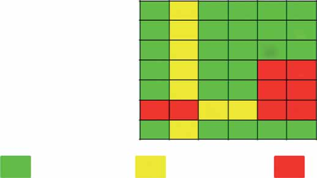

Gan *et al*. (2012)

Blinding (outcome assessor)

Blinding (participant)

Source of funding bias

Incomplete outcome data

Allocation concealment

Random sequence generation

Keles *et al*. (2010)

Chang *et al*. (2008a)

Chang *et al*. (2008b)

Pijak *et al*. (2002)

Fioravanti *et al*. (2002)

**Low risk of bias**

+

+

+

+

++

+

+

+

++

+

+

+

++

+

++

+

++

+

+

+

+

+

–

–

–

–

–

–

–

–

–

?

?

?

?

??

?

?

?

**Unclear risk of bias**

**High risk of bias**

Christensen *et al*. (2011)

Figure 2. Methodological quality summary for clinical trials: review of authors’ judgments about each methodological

quality item for each study included.

Table 3. Summary of the results of the clinical studies included in the systematic review.

Author (year)

Complexed substance

Analgesia

Comparison

Protocol assessed

Gan et al. (2012) [21]

Diclofenac

433%

vs placebo

Pain intensity differences from VAS

Christensen et al. (2011) [22]

Diclofenac

451%

vs placebo

Total pain relief from VAS

Keles et al. (2010) [23]

Piroxicam

83%

vs placebo

VAS score

Chang et al. (2008) [24]

Piroxicam

25%

vs piroxicam alone

VAS score

Chang et al. (2008) [25]

Piroxicam

42%

vs piroxicam alone

VAS score

Pijak et al. (2002) [26]

Piroxicam

66%

vs baseline

VAS score

Fioravanti et al. (2002) [27]

Nimesulide

No difference

vs naproxen

VAS score

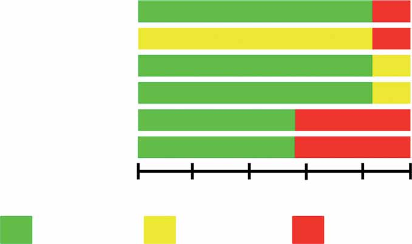

Random sequence generation

Allocation concealment

Incompleate outcome data

Source of funding bias

Blinding (participant)

Blinding (outcome assessor)

0%

**Low risk of bias**

**Unclear risk of bias**

**High risk of bias**

20%

40%

60%

80%

100%

Figure 3. Methodological quality graph for clinical studies: review of authors’ judgments about each methodological quality

item presented as percentages across all studies included.

R. G. Brito et al.

6

Expert Opin. Drug Deliv. (2015) 12(10)

For personal use only.

Siqueira-Lima et al. [28] demonstrated that the treatment

with L. grata EO complexed with bCD induced a significant

antinociceptive effect in the orofacial formalin-, capsaicin-

and glutamate-induced pain tests. Quintans-J�unior et al. [29]

showed that the LIN and LIN bCD complex (LIN-bCD)

reduced glutamate-induced nociceptive behavior and inflam-

matory cytokines in the carrageenan-induced peritonitis

model. LIN-bCD when compared with LIN alone also

showed enhanced water solubility, improved dissolution rate

and enhanced stability of LIN [59,60]. Quintans et al. [14] dem-

onstrated the antinociceptive effect of pCM and pCM-bCD

complexed in the acetic acid-induced abdominal constrictions

and hot-plate tests, and the anti-inflammatory property

through the carrageenan-induced paw edema in mice. The

study showed that pCM-bCD inhibited nociceptive behavior

for 8 h when compared with pCM alone, which showed 2 h

of inhibition in the acetic acid-writhing test. Thus, these stud-

ies show enhanced and prolonged analgesia and increased bio-

availability with CD-complexed EOs.

4.2.2 NSAIDs

The NSAIDs are clinically used in different diseases, to reduce

fever, pain, stiffness and swelling [30,61-69]. That class of drugs

has been complexed in CDs and tested in different experi-

mental models to optimize their pharmacological effects.

When complexed with CDs, indomethacin, etoricoxib and

etodolac show enhanced efficacy in the tail-flick test and

hot-plate test [30,32,34]. Similarly, in the acetic acid-writhing

**A.**

**Studies**

Estimate (95% C.I.)

**B.**

**Studies**

Estimate (95% C.I.)

**C.**

**Studies**

Estimate (95% C.I.)

Dolita 2012

Quintans-Junior *et al*. 2013

Quintans-Junior *et al*. 2013

El-feky *et al*. 2013

Quintans *et al*. 2012

Quintans *et al*. 2013

Lima *et al*. 2012

Sammeta *et al*. 2010

Janovysky *et al*. 2010

Capello *et al*. 2009

Lu *et al*. 2004

Overall (I<sup>2</sup>= 89% , p < 0.001)

Overall (I<sup>2</sup>= 75% , p = 0.007)

Overall (I<sup>2</sup>= 97% , p = 0.001)

Sinha & Goel 2010

Sinha & Goel 2010

–9.021

–1.527

10.352

6.000

(2.884, 9.116)

(0.986, 10.614)

(–16.024, 20.024)

(2.334, 11.666)

(22.568, 33.432)

(–2.714, 16.714)

(–5.804, 36.404)

(–2.975, –0.025)

(–25.786, –3.814)

(–17.987, 1.387)

(–32.443, –3.557)

(–17.435, –0.607)

(3.184, 17.521)

2.000

7.000

7.000

15.300

–1.500

–14.800

–8.300

–18.000

(–0.653, 0.453)

(–3.905, –2.095)

(–4.369, 1.315)

**Mean Difference**

**Mean Difference**

**Mean Difference**

–4

–3

–2

–1

0

1

–30

30

–25

–20

20

–15

–5

–10

10

–10

0

0

–0.100

–3.000

28.000

5.800

C. nociception score.

CDs improving analgesic drugs

Expert Opin. Drug Deliv. (2015) 12(10)

7

For personal use only.

test, meloxicam, etodolac, ketoprofen and acetyl salicylic acid

showed a greater reduction in nociception when complexed in

CDs than when administered alone [31,33-36]. Furthermore,

CDs improved the solubility of indomethacin [30], enhanced

the solubility, dissolution and permeability of meloxi-

cam [70,71], and enhanced absorption of etodolac [34]. For

instance, Sinha and Goel [34] showed an increase in the t1/2

and decrease in the elimination rate for CD-complexed etodo-

lac compared to the drug alone. In addition, lower ulcero-

genic activity occurs with CD-complexed etodolac alone as

the average number of ulcerations was reduced in approxi-

mately 50% in the presence of the CDs examined. Thus,

the NSAIDs complexed to CDs show enhanced analgesia,

improved bioavailability and reduced side effects when com-

pared with the drug alone.

4.2.3 Other analgesic drugs

Drugs from a variety of different classes have also been tested

in the complexed form to check for a possible improvement in

their analgesic activity. Those include studies with cannabi-

noids, steroids, local anesthetics, opioids and antidepressants.

MDA7, a selective CB2 agonist, suppresses allodynia in rats

with spinal nerve ligation or paclitaxel-induced neuropathic

pain [72,73]. In animals with neuropathic pain induced by spi-

nal nerve ligation, MDA7 formulated in HPbCD produces a

greater reduction in mechanical hyperalgesia when compared

with the vehicle [37].

Allopregnanolone and alphaxalone are neurosteroids that

probably

facilitate

activation

by

g-amino

butyric

acid

(GABA) of the GABAA chloride ionophore and at higher con-

centrations by directly activating the ionophore, promoting

the channel open state [74-76]. Svensson et al. [38] showed that

the intrathecal delivery of 5a-reduced neurosteroid agonist

allopregnanolone and alphaxalone in a CD-water-based

vehicle shows a greater reduction in thermal and mechanical

hyperalgesia in the unilateral intraplantar delivery of carra-

geenan model when compared with the vehicle.

TTC is a member of the ester class of local anesthetics that

is used to anesthetize nasal tissues before diagnostic and surgi-

cal procedures [77]. Lima et al. [39] evaluated the antinocicep-

tive

effect

induced

by

TTC

complexes

through

the

infraorbital nerve blockade test in rats and showed that the

complexation with HPbCD and bCD increased the analgesic

duration and intensity induced by TTC alone. The authors

also demonstrated that the treatment of 3T3 cultured cells

with TTC showed an increase in the LD50 following com-

plexation, reflecting a reduction in the cytotoxicity of TTC

upon the complexation of either bCD or HPbCD.

commonly

used

in

the

surgical

room

[78,79].

Volobuef et al. [40] demonstrated that the latency to the

tail-flick was increased after the complexation of SUF with

HPbCD when compared with the free drug. SUF-HPbCD

also changed hemolytic concentrations, which is possible

because the CDs change the drug permeation across the

membranes or its distribution, prolonging the effects,

decreasing the plasmatic levels and reducing the systemic

toxicity [79,80].

in

addition

to

depression

and

anxiety

disorders [81-83]. Sammeta et al. [41] demonstrated that the

electroporation of CD-complexed DOX resulted in the

retention of significant amounts of drug in epidermis and

sustained drug release from the epidermis. In the study, a

prolonged analgesic activity measured with the pain avoiding

response using a blunt needle model was observed in the

CDs group of rats when compared with the pure drug solu-

tion group.

Table 4. Summary of the results of the preclinical studies included in the systematic review.

Author (year)

Complexed substance

Other aspects improved

Clinical

Christensen et al. (2011) [22]

Diclofenac

Time action

Fioravanti et al. (2002) [27]

Nimesulide

Gastrointestinal tolerability

Preclinical

Siqueira-Lima et al. (2014) [28]

Lippia grata essential oil

Solubility

Quintans-J�unior et al. (2013) [29]

(-)-Linalool

Solubility

Quintans et al. (2013) [14]

p-Cymene

Solubility and time action

El-Feky et al. (2013) [30]

Indomethacin

Solubility and oral delivery

Dolita (2012) [31]

Acetyl salicylic acid

Permeability and solubility

Singh et al. (2011) [32]

Etoricoxib

Solubility

Sinha and Goel (2010) [34]

Etodolac

Bioavailability and absorption

Capello et al. (2009) [35]

Etodolac

Gastrolesivity reduction and solubility

Lu et al. (2004) [36]

Ketoprofen

Solubility and absorption

Astruc-Diaz et al. (2013) [37]

MDA7

Solubility

Franco de Lima et al. (2012) [39]

Tetracaine

Time action and cytotoxicity decrease

Volobuef et al. (2012) [40]

Sufentanil

Time action and cytotoxicity decrease

Sammeta et al. (2010) [41]

Doxepin

Drug release

R. G. Brito et al.

8

Expert Opin. Drug Deliv. (2015) 12(10)

For personal use only.

5. Conclusion

This systematic review found clinical and preclinical studies

that tested a variety of drugs complexed with different types

of CDs. Clinical studies showed greater efficacy of NSAIDs

complexed with CDs in a variety of conditions. The preclini-

cal studies demonstrated that the CD complexions were capa-

ble of producing analgesic profile in several animal models of

nociception, having better effects than the drugs alone. These

preclinical studies also showed greater bioavailability of the

drug and reduced side effects. Thus, complexation of drugs

with CD may be an important delivery method to improve

analgesic efficacy by reducing therapeutic doses and the conse-

quent side effects.

6. Expert opinion

The CDs have mainly been used for many purposes, as com-

plexing agents to increase aqueous solubility of poorly soluble

drugs, to increase their bioavailability and stability and also to

improve drug delivery from almost any type of drug formula-

tion. Along with that, the relatively low cost and easy acquisi-

tion are factors that place the CDs as continuously interesting

drug delivery systems. Therefore, CDs continue to have

different applications in different areas such as food and

pharmaceutical industries.

All these promising characteristics of CDs have motivated

the researchers to find a way to improve the effects of drugs

with analgesic activity, which may also reduce the side effects

and improve the pharmacological efficacy. Our systematic

review found different clinical and preclinical studies that

tested some drugs, with analgesic effect, complexed in differ-

ent types of CDs. Therefore, it was possible to demonstrate

that the use of these drug delivery systems was able to improve

the pharmacological effects of drugs, provide a more rapid

onset of action and increase the duration of activity in

humans.

The preclinical studies demonstrated that the CD complex-

ions were capable of producing analgesic profile in several

animal models of nociception, having better effects than the

drugs alone (non-complexed drug). The clinical studies

showed that the CD complexation was able to increase the

analgesic activity of compounds widely used nowadays, such

as PX and DF.

Consequently, the use of new formulations with CDs is an

important tool in the search for greater analgesic effect, and it

may also be a way to reduce the therapeutic doses, increasing

the potential of the drug. On the other hand, it is necessary to

investigate possible interactions between these agents and

other formulations, once the interaction can adversely affect

the performance of both.

In summary, the use of CDs makes it possible to construct

different pharmaceutical formulations, like capsules and gels,

and optimize the chemical configuration of some drug mole-

cules that can improve the pharmacokinetics and dynamic

profiles, which can result in a better toxicity and side effect

profiles. In this context, it is expected that the CDs can solve

many problems associated with the delivery of different novel

drugs through different delivery routes that may improve the

prognosis of certain diseases, particularly those with severe

pain as a symptom, like cancer, fibromyalgia, arthritis and

neuropathy, offering a better quality of life to patients,

caregivers and family members.

Acknowledgments

RG Brito is a doctoral student in a sandwich model and

LJ Quintans-J�unior had a post-doctoral stage at the University

of Iowa (UIOWA). We thank Emine O Bayman for the

methodological support.

Declaration of interest

This work was supported by grants from the National Coun-

cil of Technological and Scientific Development (CNPq/

Brazil), the Research Supporting Foundation of the State of

Sergipe (FAPITEC-SE/Brazil) and Coordinating Develop-

ment of Senior Staff (CAPES/Brazil). The authors have no

other relevant affiliations or financial involvement with any

organization or entity with a financial interest in or financial

conflict with the subject matter or materials discussed in the

manuscript. This includes employment, consultancies, hono-

raria, stock ownership or options, expert testimony, grants

or patents received or pending, or royalties.

CDs improving analgesic drugs

Expert Opin. Drug Deliv. (2015) 12(10)

9

For personal use only.

Bibliography

Papers of special note have been highlighted as

either of interest (�) or of considerable interest

(��) to readers.

1.

Azevedo LF, Costa-Pereira A,

Mendonc¸a L, et al. Epidemiology of

chronic pain: a population-based

nationwide study on its prevalence,

characteristics and associated disability in

Portugal. J Pain 2012;13:773-83

2.

Manchikanti L, Ailinani H,

Koyyalagunta D, et al. A systematic

review of randomized trials of long-term

opioid management for chronic non-

cancer pain. Pain Physician

2011;14:91-121

3.

Harker J, Reid KJ, Bekkering GE, et al.

Epidemiology of chronic pain in

denmark and sweden. Pain Res Treat

2012;2012:371248

4.

Gaskin DJ, Richard P. The economic

costs of pain in the United States. J Pain

2012;13:715-24

5.

Dionne RA. Pharmacologic treatments

for temporomandibular disorders.

Oral Surg Oral Med Oral Pathol Oral

Radiol Endod 1997;83:134-42

6.

Becker DE. Pain management: Part 1:

Managing acute and postoperative dental

pain. Anesth Prog 2010;57:67-78

7.

Clauw DJ, Arnold LM, McCarberg BH.

The science of fibromyalgia.

Mayo Clin Proc 2011;86:907-11

8.

Xu B, Descalzi G, Ye H-R, et al.

Translational investigation and treatment

of neuropathic pain. Mol Pain 2012;8:15

9.

Abdel-Tawab M, Zettl H,

Schubert-Zsilavecz M. Nonsteroidal anti-

inflammatory drugs: a critical review on

current concepts applied to reduce

gastrointestinal toxicity. Curr Med Chem

2009;16:2042-63

10.

Laza-Knoerr AL, Gref R, Couvreur P.

Cyclodextrins for drug delivery.

J Drug Target 2010;18:645-56

..

Describes how useful is

the cyclodextrins.

11.

Loftsson T, Brewster ME.

Pharmaceutical applications of

cyclodextrins. 1. Drug solubilization and

stabilization. J Pharm Sci

1996;85:1017-25

..

Describes the pharmaceutical

importance of cyclodextrins.

12.

Scarpignato C. Piroxicam-b-cyclodextrin:

a GI safer piroxicam. Curr Med Chem

2013;20:2415-37

13.

Del Valle EMM. Cyclodextrins and their

uses: a review. Process Biochem

2004;39:1033-46

..

Describes the different use

of cyclodextrins.

14.

Quintans J de SS, Menezes PP,

Santos MRV, et al. Improvement of

p-cymene antinociceptive and anti-

inflammatory effects by inclusion in

b-cyclodextrin. Phytomedicine

2013;20:436-40

15.

Tejashri G, Amrita B, Darshana J.

Cyclodextrin based nanosponges for

pharmaceutical use: a review. Acta Pharm

Zagreb Croat 2013;63:335-58

16.

Pinho E, Grootveld M, Soares G,

Henriques M. Cyclodextrins as

encapsulation agents for plant bioactive

compounds. Carbohydr Polym

2014;101:121-35

17.

Stella VJ, He Q. Cyclodextrins.

Toxicol Pathol 2008;36:30-42

.

Helps understand what is cyclodextrin.

18.

Challa R, Ahuja A, Ali J, Khar RK.

Cyclodextrins in drug delivery: An

updated review. AAPS PharmSciTech

2005;6:E329-57

.

Helps to understand how cyclodextrin

is used in drug delivery.

19.

Moher D, Liberati A, Tetzlaff J,

Altman DG. Preferred reporting items

for systematic reviews and meta-analyses:

the PRISMA statement. Ann Intern Med

2009;151:264-9; W64

20.

Higgins JPT, Altman DG, G?tzsche PC,

et al. The Cochrane Collaboration’s tool

for assessing risk of bias in randomised

trials. BMJ 2011;343:d5928

21.

Gan TJ, Daniels SE, Singla N, et al.

A novel injectable formulation of

diclofenac compared with intravenous

ketorolac or placebo for acute

moderate-to-severe pain after abdominal

or pelvic surgery: a multicenter, double-

blind, randomized, multiple-dose study.

Anesth Analg 2012;115:1212-20

22.

Christensen K, Daniels S, Bandy D,

et al. A double-blind placebo-controlled

comparison of a novel formulation of

intravenous diclofenac and ketorolac for

postoperative third molar extraction pain.

Anesth Prog 2011;58:73-81

23.

Keles¸ GT, Topc¸u I, Ekici Z, Yentu¨r A.

Evaluation of piroxicam-beta-cyclodextrin

as a preemptive analgesic in functional

endoscopic sinus surgery. Braz J Med

Biol Res 2010;43:806-11

24.

Chang S-T, Chen L-C, Chang C-C,

et al. Effects of

piroxicam-beta-cyclodextrin sachets on

abnormal postural sway in patients with

chronic low back pain.

J Clin Pharm Ther 2008;33:495-506

25.

Shin-Tsu Chang L-CC. Efficacy and

safety of piroxicam beta-cyclodextrin

sachets for treating chronic low back

pain: a randomized, parallel, active-

controlled trial. J Med Sci 2008;28

26.

Pijak MR, Turcani P, Turcaniova Z,

et al. Efficacy and tolerability of

piroxicam-beta-cyclodextrin in the

outpatient management of chronic back

pain. Bratisl Leka´rske Listy

2002;103:467-72

27.

Fioravanti A, Storri L, Di Martino S,

et al. A randomized, double-blind,

multicenter trial of

nimesulide-beta-cyclodextrin versus

naproxen in patients with osteoarthritis.

Clin Ther 2002;24:504-19

28.

Siqueira-Lima PS, Ara�ujo AAS,

Lucchese AM, et al. b-cyclodextrin

complex containing lippia grata leaf

essential oil reduces orofacial nociception

in mice - evidence of possible

involvement of descending inhibitory

pain modulation pathway. Basic Clin

Pharmacol Toxicol 2014;114:188-96

29.

Quintans-J�unior LJ, Barreto RSS,

Menezes PP, et al.

b-Cyclodextrin-complexed (-)-linalool

produces antinociceptive effect superior

to that of (-)-linalool in experimental

pain protocols. Basic Clin

Pharmacol Toxicol 2013;113:167-72

30.

El-Feky G, El-Banna S, Khalil S.

Preparation, in vitro and in vivo

evaluation of oral indomethacin-HP-B-

Cyclodextrin loaded chitosan

nanoparticules. Int J Pharm Pharm Sci

2013;5:638-45

31.

Dolita K. Formulation and

characterization of inclusion complex of

acetyl salicylic acid (aspirin) and

b-cyclodextrin vy solvent evaporation &

its comparatives study to aspirin alone.

Int J Pharm Sci Res 2012;3:2831-6

R. G. Brito et al.

10

Expert Opin. Drug Deliv. (2015) 12(10)

For personal use only.

32.

Singh I, Kumar P, Pahuja S, et al.

Development and pharmacological

evaluation of cyclodextrin complexes of

etoricoxib. Acta Pol Pharm

2011;68:279-84

33.

Janovsky´ M, Dolezal T, Procha´izkova´ M,

et al. Influence on analgesic activity and

serum levels after meloxicam

complexation with beta-cyclodextrin in

mice and rats. Arzneimittelforschung

2010;60:320-3

34.

Sinha VR, Amita Goel H. In vivo

bioavailability and therapeutic assessment

of host-guest inclusion phenomena for

the hydrophobic molecule etodolac:

pharmacodynamic and pharmacokinetic

evaluation. Sci Pharm 2010;78:103-15

35.

Cappello B, di Maio C, Iervolino M,

et al. Etodolac/cyclodextrin formulations:

physicochemical characterization and

in vivo pharmacological studies.

Drug Dev Ind Pharm 2009;35:877-86

36.

Lu W-L, Zhang Q, Zheng L, et al.

Antipyretic, analgesic and anti-

inflammatory activities of ketoprofen

beta-cyclodextrin inclusion complexes in

animals. Biol Pharm Bull

2004;27:1515-20

37.

Astruc-Diaz F, McDaniel SW, Xu JJ,

et al. In vivo efficacy of enabling

formulations based on hydroxypropyl-b-

cyclodextrins, micellar preparation, and

liposomes for the lipophilic cannabinoid

CB2 agonist, MDA7. J Pharm Sci

2013;102:352-64

38.

Svensson E, Persson J, Fitzsimmons B,

Yaksh TL. Intrathecal neurosteroids and

a neurosteroid antagonist: effects on

inflammation-evoked thermal

hyperalgesia and tactile allodynia.

Neurosci Lett 2013;548:27-32

39.

Franco de Lima RA, de Jesus MB,

Saia Cereda CM, et al. Improvement of

tetracaine antinociceptive effect by

inclusion in cyclodextrins. J Drug Target

2012;20:85-96

40.

Volobuef C, Moraes CM, Nunes LAS,

et al. Sufentanil-2-hydroxypropyl-b-

cyclodextrin inclusion complex for pain

treatment: physicochemical, cytotoxicity,

and pharmacological evaluation.

J Pharm Sci 2012;101:3698-707

41.

Sammeta SM, Vaka SRK, Murthy SN.

Transcutaneous electroporation mediated

delivery of doxepin-HPCD complex:

a sustained release approach for

treatment of postherpetic neuralgia.

J Control Release Off 2010;142:361-7

42.

Gan TJ. Diclofenac: an update on its

mechanism of action and safety profile.

Curr Med Res Opin 2010;26:1715-31

43.

Marret E, Kurdi O, Zufferey P,

Bonnet F. Effects of nonsteroidal

antiinflammatory drugs on patient-

controlled analgesia morphine side

effects: meta-analysis of randomized

controlled trials. Anesthesiology

2005;102:1249-60

44.

McCormack K. Non-steroidal anti-

inflammatory drugs and spinal

nociceptive processing. Pain

1994;59:9-43

45.

Koes B, Scholten R, Mens J, Bouter L.

Efficacy of non-steroidal anti-

inflammatory drugs for low back pain:

a systematic review of randomised

clinical trials. Ann Rheum Dis

1997;56:214-23

46.

Acerbi DD. Pharmacokinetic Profile of

Piroxicam-b-Cyclodextrin. Drug Investig

1990;2:42-9

47.

Woodcock BG, Acerbi D, Merz PG,

et al. Supermolecular inclusion of

piroxicam with beta-cyclodextrin:

pharmacokinetic properties in man. Eur J

Rheumatol Inflamm 1993;12:12-28

48.

Lee CR, Balfour JA. Piroxicam-beta-

cyclodextrin. A review of its

pharmacodynamic and pharmacokinetic

properties, and therapeutic potential in

rheumatic diseases and pain states. Drugs

1994;48:907-29

49.

Davoli L, Ciotti G, Biondi M,

Passeri M. Piroxicam-beta-cyclodextrin in

the treatment of low-back pain:

controlled study vs etodolac.

Curr Ther Res 1989;46:940-7

50.

Rainsford KD. Nimesulide – a

multifactorial approach to inflammation

and pain: scientific and clinical

consensus. Curr Med Res Opin

2006;22:1161-70

51.

Batista PA, Werner MF de P,

Oliveira EC, et al. Evidence for the

involvement of ionotropic glutamatergic

receptors on the antinociceptive effect of

(-)-linalool in mice. Neurosci Lett

2008;440:299-303

52.

Elisabetsky E, Brum LF, Souza DO.

Anticonvulsant properties of linalool in

glutamate-related seizure models.

Phytomedicine 1999;6:107-13

53.

Venaˆncio AM, Marchioro M,

Estavam CS, et al. Ocimum basilicum

leaf essential oil and (-)-linalool reduce

orofacial nociception in rodents:

a behavioral and electrophysiological

approach. Rev Bras Farmacogn

2011;21:1043-51

54.

Siani AC, Ramos MF, Menezes-de-

Lima O Jr, et al. Evaluation of

anti-inflammatory-related activity of

essential oils from the leaves and resin of

species of Protium. J Ethnopharmacol

1999;66:57-69

55.

Bonjardim LR, Cunha ES,

Guimara˜es AG, et al. Evaluation of the

anti-inflammatory and antinociceptive

properties of p-cymene in mice. Z Fu¨r

Naturforschung C J Biosci

2012;67:15-21

56.

Xie G, Chen N, Soromou LW, et al.

p-Cymene protects mice against

lipopolysaccharide-induced acute lung

injury by inhibiting inflammatory cell

activation. Mol Basel Switz

2012;17:8159-73

57.

Marreto RN, Almeida EECV, Alves PB,

et al. Thermal analysis and gas

chromatography coupled mass

spectrometry analyses of

hydroxypropyl-b-cyclodextrin inclusion

complex containing Lippia gracilis

essential oil. Thermochim Acta

2008;475:53-8

58.

Menezes PP, Serafini MR, Santana BV,

et al. Solid-state b-cyclodextrin

complexes containing geraniol.

Thermochim Acta 2012;548:45-50

59.

Ciobanu A, Mallard I, Landy D, et al.

Inclusion interactions of cyclodextrins

and crosslinked cyclodextrin polymers

with linalool and camphor in Lavandula

angustifolia essential oil.

Carbohydr Polym 2012;87:1963-70

60.

Menezes PP, Serafini MR,

Quintans-J�unior LJ, et al. Inclusion

complex of (-)-linalool and

b-cyclodextrin. J Therm Anal Calorim

2014;115:2429-2437

61.

Dillon CT, Hambley TW, Kennedy BJ,

et al. Gastrointestinal toxicity,

antiinflammatory activity, and superoxide

dismutase activity of copper and zinc

complexes of the antiinflammatory drug

indomethacin. Chem Res Toxicol

2003;16:28-37

62.

Moon H-G, Kang CS, Choi J-P, et al.

Acetyl salicylic acid inhibits Th17 airway

inflammation via blockade of IL-6 and

IL-17 positive feedback. Exp Mol Med

2013;45:e6

CDs improving analgesic drugs

Expert Opin. Drug Deliv. (2015) 12(10)

11

For personal use only.

63.

Rubin BR, Burton R, Navarra S, et al.

Efficacy and safety profile of treatment

with etoricoxib 120 mg once daily

compared with indomethacin 50 mg

three times daily in acute gout:

A randomized controlled trial.

Arthritis Rheum 2004;50:598-606

64.

Schnitzer TJ, Hochberg MC.

COX-2-selective inhibitors in the

treatment of arthritis. Cleve Clin J Med

2002;69:SI20

65.

Akbulut N, Ustu¨ner E, Atakan C,

C€olok G. Comparison of the effect of

naproxen, etodolac and diclofenac on

postoperative sequels following third

molar surgery: A randomised, double-

blind, crossover study. Med Oral Patol

2014;19:e149-56

66.

Kaur N, Singh H, Gupta AC.

Randomized Controlled Trial of

Etodolac versus Combination of Etodolac

and Eperisone in Patients of Knee

Osteoarthritis. Pain Res Treat

2013;2013:273695

67.

Duangjit S, Obata Y, Sano H, et al.

Comparative study of novel

ultradeformable liposomes: menthosomes,

transfersomes and liposomes for

enhancing skin permeation of

meloxicam. Biol Pharm Bull

2014;37:239-47

68.

Mas´lanka T, Jaroszewski JJ. In vitro

effects of meloxicam on the number,

Foxp3 expression, production of selected

cytokines, and apoptosis of bovine CD25

+CD4+ and CD25-CD4+ cells. J Vet Sci

2013;14:125-34

69.

Carbone C, Rende P, Comberiati P,

et al. The safety of ketoprofen in

different ages. J Pharmacol Pharmacother

2013;4:S99-S103

70.

Saleem MA, Bala S, Liyakat Aeajaz A.

Effect of Different Carriers on in vitro

Permeation of Meloxicam through Rat

Skin. Indian J Pharm Sci

2010;72:710-18

71.

Ghorab MM, Abdel-Salam HM,

El-Sayad MA, Mekhel MM. Tablet

formulation containing meloxicam and

beta-cyclodextrin: Mechanical

characterization and bioavailability

evaluation. AAPS PharmSciTech

2004;5:63-8

72.

Naguib M, Diaz P, Xu JJ, et al. MDA7:

a novel selective agonist for

CB2 receptors that prevents allodynia in

rat neuropathic pain models.

Br J Pharmacol 2008;155:1104-16

73.

Naguib M, Xu JJ, Diaz P, et al.

Prevention of paclitaxel-induced

neuropathy through activation of the

central cannabinoid type 2 receptor

system. Anesth Analg 2012;114:1104-20

74.

Akk G, Covey DF, Evers AS, et al.

Mechanisms of neurosteroid interactions

with GABAA receptors. Pharmacol Ther

2007;116:35-57

75.

Jevtovic-Todorovic V, Covey DF,

Todorovic SM. Are neuroactive steroids

promising therapeutic agents in the

management of acute and chronic pain?

Psychoneuroendocrinology

2009;34:S178-85

76.

Reddy DS. Neurosteroids: endogenous

role in the human brain and therapeutic

potentials. Prog Brain Res

2010;186:113-37

77.

Giannakopoulos H, Levin LM, Chou JC,

et al. The cardiovascular effects and

pharmacokinetics of intranasal tetracaine

plus oxymetazoline Preliminary findings.

J Am Dent Assoc 2012;143:872-80

78.

Wilhelm W, Kreuer S. The place for

short-acting opioids: special emphasis on

remifentanil. Crit Care 2008;12:S5

79.

Rajewski RA, Stella VJ. Pharmaceutical

applications of cyclodextrins. 2. In vivo

drug delivery. J Pharm Sci

1996;85:1142-69

80.

Irie T, Uekama K. Pharmaceutical

applications of cyclodextrins. III.

Toxicological issues and safety evaluation.

J Pharm Sci 1997;86:147-62

81.

Hajak G, Rodenbeck A, Voderholzer U,

et al. Doxepin in the treatment of

primary insomnia: a placebo-controlled,

double-blind, polysomnographic study.

J Clin Psychiatry 2001;62:453-63

82.

Drake LA, Fallon JD, Sober A. Relief of

pruritus in patients with atopic dermatitis

after treatment with topical doxepin

cream. J Am Acad Dermatol

1994;31:613-16

83.

Gharzi M, Dolatabadi HRD, Reisi P,

Javanmard SH. Effects of different doses

of doxepin on passive avoidance learning

in rats. Adv Biomed Res 2013;2:66

Affiliation

Renan G Brito<sup>1,2</sup>, Adriano AS Ara�ujo<sup>3</sup>,

Jullyana SS Quintans<sup>1</sup>,

Kathleen A Sluka<sup>2</sup>&

Lucindo J Quintans-J�unior†<sup>1,2</sup>

†Author for correspondence

1Federal University of Sergipe, Department of

Physiology, Sa˜o Cristo´va˜o, Sergipe, Brazil

Fax: +55 79 2105 6640;

E-mail: lucindojr@gmail.com;

lucindo@pq.cnpq.br

2University of Iowa, Carver College of Medicine,

Physical Therapy and Rehabilitation Science,

Iowa City, IA, USA

3Federal University of Sergipe, Department of

Pharmacy, Sa˜o Cristo´va˜o, Sergipe, Brazil

R. G. Brito et al.

12

Expert Opin. Drug Deliv. (2015) 12(10)

For personal use only.